# INTRODUCTION

The data set gives an insight of an hospital having patient who do not show up for their appointment day, and would try in predicting the which of the factors are the likely cause of this. So i would be using pandas, numpy and matplotlib, to try and predict which feature has good correlation with the target variable. The data specifcally is about how an hospital ssems to negivate a problem why some of their patient miss/ do not show up on their appoinment day. Below is a brief decription of what the dataset looks like;

#### Age - How old is the patient.

#### Neighbourhood - Where the appointment takes place.

#### Scholarship - True of False

#### Hipertension - True of False

#### Diabetes - True of False

#### Alcoholism - True of False

#### Handcap - True of False

#### SMS_received - 1 or more messages sent to the patient

#### No-show - True of False

# Questions that i found useful in getting insight, and i can explore.

Now i am going to the check how, why, the independent variables relates with the depent variable (No show). Below are some set of questions to be used to answer the question;

# 1. What percentage of patient show up and didn't?

# 2.Which of the Gender misses their appiontment day or did not show up

# 3.How many of the patient took the scholarship and show up, and What percentage of patient who took the scholarship and did not?

# 4.how many patient received sms and attended their appointment?

# 5. Is SMS_received and gender affect the patient's show up?

# 6 Is any deseases (Hipertension , Diabetes ) affect the patient's show up?

```python
import numpy as np
import pandas as pd
import matplotlib.pyplot as plt
import seaborn as sns
%matplotlib inline
```

```python
app_df = pd.read_csv('KaggleV2-May-2016.csv')
app_df.head()
```

|  | PatientId | AppointmentID | Gender | ScheduledDay | AppointmentDay | Age | Neighbourhood | Scholarship | Hipertension | Diabetes | Alcoholism | Handcap | SMS_received | No-show |
| --- | --- | --- | --- | --- | --- | --- | --- | --- | --- | --- | --- | --- | --- | --- |
| 0 | 2.987250e+13 | 5642903 | F | 2016-04-29T18:38:08Z | 2016-04-29T00:00:00Z | 62 | JARDIM DA PENHA | 0 | 1 | 0 | 0 | 0 | 0 | No |
| 1 | 5.589978e+14 | 5642503 | M | 2016-04-29T16:08:27Z | 2016-04-29T00:00:00Z | 56 | JARDIM DA PENHA | 0 | 0 | 0 | 0 | 0 | 0 | No |
| 2 | 4.262962e+12 | 5642549 | F | 2016-04-29T16:19:04Z | 2016-04-29T00:00:00Z | 62 | MATA DA PRAIA | 0 | 0 | 0 | 0 | 0 | 0 | No |
| 3 | 8.679512e+11 | 5642828 | F | 2016-04-29T17:29:31Z | 2016-04-29T00:00:00Z | 8 | PONTAL DE CAMBURI | 0 | 0 | 0 | 0 | 0 | 0 | No |
| 4 | 8.841186e+12 | 5642494 | F | 2016-04-29T16:07:23Z | 2016-04-29T00:00:00Z | 56 | JARDIM DA PENHA | 0 | 1 | 1 | 0 | 0 | 0 | No |

### DATA WRANGING

```python
app_df.info()
```

```
<class 'pandas.core.frame.DataFrame'>
RangeIndex: 110527 entries, 0 to 110526
Data columns (total 14 columns):
 #   Column          Non-Null Count   Dtype
---  ------          --------------   -----
 0   PatientId       110527 non-null  float64
 1   AppointmentID   110527 non-null  int64
 2   Gender          110527 non-null  object
 3   ScheduledDay    110527 non-null  object
 4   AppointmentDay  110527 non-null  object
 5   Age             110527 non-null  int64
 6   Neighbourhood   110527 non-null  object
 7   Scholarship     110527 non-null  int64
 8   Hipertension    110527 non-null  int64
 9   Diabetes        110527 non-null  int64
 10  Alcoholism      110527 non-null  int64
 11  Handcap         110527 non-null  int64
 12  SMS_received    110527 non-null  int64
 13  No-show         110527 non-null  object
dtypes: float64(1), int64(8), object(5)
memory usage: 11.8+ MB
```

```python
app_df.shape
```

```
(110527, 14)
```

```python
app_df.describe()
```

|  | PatientId | AppointmentID | Age | Scholarship | Hipertension | Diabetes | Alcoholism | Handcap | SMS_received |
| --- | --- | --- | --- | --- | --- | --- | --- | --- | --- |
| count | 1.105270e+05 | 1.105270e+05 | 110527.000000 | 110527.000000 | 110527.000000 | 110527.000000 | 110527.000000 | 110527.000000 | 110527.000000 |
| mean | 1.474963e+14 | 5.675305e+06 | 37.088874 | 0.098266 | 0.197246 | 0.071865 | 0.030400 | 0.022248 | 0.321026 |
| std | 2.560949e+14 | 7.129575e+04 | 23.110205 | 0.297675 | 0.397921 | 0.258265 | 0.171686 | 0.161543 | 0.466873 |
| min | 3.921784e+04 | 5.030230e+06 | -1.000000 | 0.000000 | 0.000000 | 0.000000 | 0.000000 | 0.000000 | 0.000000 |
| 25% | 4.172614e+12 | 5.640286e+06 | 18.000000 | 0.000000 | 0.000000 | 0.000000 | 0.000000 | 0.000000 | 0.000000 |
| 50% | 3.173184e+13 | 5.680573e+06 | 37.000000 | 0.000000 | 0.000000 | 0.000000 | 0.000000 | 0.000000 | 0.000000 |
| 75% | 9.439172e+13 | 5.725524e+06 | 55.000000 | 0.000000 | 0.000000 | 0.000000 | 0.000000 | 0.000000 | 1.000000 |
| max | 9.999816e+14 | 5.790484e+06 | 115.000000 | 1.000000 | 1.000000 | 1.000000 | 1.000000 | 4.000000 | 1.000000 |

# CLEANING THE DATA SET

Looking as the describe function;

1. the Age column has a min value of -1 which i feel is not right and there are no aga below zero(0) in real life
2. the patientid column data type is in float, so some ab=djustment needs to be done to convert it from i=float to int
3. Also, changing the appointmentday and scheduleday to the appropriate format

```python
#checking for missing values in the data set
app_df.isnull().sum()
```

```
PatientId         0
AppointmentID     0
Gender            0
ScheduledDay      0
AppointmentDay    0
Age               0
Neighbourhood     0
Scholarship       0
Hipertension      0
Diabetes          0
Alcoholism        0
Handcap           0
SMS_received      0
No-show           0
dtype: int64
```

Looking at the data set, there is no missing values found

```python
# checking for numbers ofrows with -1 year in the data set
app_df[app_df['Age'] == -1]


# droping the rows with -1 year for the Age column
app_df.drop(labels=99832, axis=0, inplace=True)

#resisting the row number in the dataframe
app_df.reset_index(inplace =False)
```

|  | index | PatientId | AppointmentID | Gender | ScheduledDay | AppointmentDay | Age | Neighbourhood | Scholarship | Hipertension | Diabetes | Alcoholism | Handcap | SMS_received | No-show |
| --- | --- | --- | --- | --- | --- | --- | --- | --- | --- | --- | --- | --- | --- | --- | --- |
| 0 | 0 | 2.987250e+13 | 5642903 | F | 2016-04-29T18:38:08Z | 2016-04-29T00:00:00Z | 62 | JARDIM DA PENHA | 0 | 1 | 0 | 0 | 0 | 0 | No |
| 1 | 1 | 5.589978e+14 | 5642503 | M | 2016-04-29T16:08:27Z | 2016-04-29T00:00:00Z | 56 | JARDIM DA PENHA | 0 | 0 | 0 | 0 | 0 | 0 | No |
| 2 | 2 | 4.262962e+12 | 5642549 | F | 2016-04-29T16:19:04Z | 2016-04-29T00:00:00Z | 62 | MATA DA PRAIA | 0 | 0 | 0 | 0 | 0 | 0 | No |
| 3 | 3 | 8.679512e+11 | 5642828 | F | 2016-04-29T17:29:31Z | 2016-04-29T00:00:00Z | 8 | PONTAL DE CAMBURI | 0 | 0 | 0 | 0 | 0 | 0 | No |
| 4 | 4 | 8.841186e+12 | 5642494 | F | 2016-04-29T16:07:23Z | 2016-04-29T00:00:00Z | 56 | JARDIM DA PENHA | 0 | 1 | 1 | 0 | 0 | 0 | No |
| ... | ... | ... | ... | ... | ... | ... | ... | ... | ... | ... | ... | ... | ... | ... | ... |
| 110521 | 110522 | 2.572134e+12 | 5651768 | F | 2016-05-03T09:15:35Z | 2016-06-07T00:00:00Z | 56 | MARIA ORTIZ | 0 | 0 | 0 | 0 | 0 | 1 | No |
| 110522 | 110523 | 3.596266e+12 | 5650093 | F | 2016-05-03T07:27:33Z | 2016-06-07T00:00:00Z | 51 | MARIA ORTIZ | 0 | 0 | 0 | 0 | 0 | 1 | No |
| 110523 | 110524 | 1.557663e+13 | 5630692 | F | 2016-04-27T16:03:52Z | 2016-06-07T00:00:00Z | 21 | MARIA ORTIZ | 0 | 0 | 0 | 0 | 0 | 1 | No |
| 110524 | 110525 | 9.213493e+13 | 5630323 | F | 2016-04-27T15:09:23Z | 2016-06-07T00:00:00Z | 38 | MARIA ORTIZ | 0 | 0 | 0 | 0 | 0 | 1 | No |
| 110525 | 110526 | 3.775115e+14 | 5629448 | F | 2016-04-27T13:30:56Z | 2016-06-07T00:00:00Z | 54 | MARIA ORTIZ | 0 | 0 | 0 | 0 | 0 | 1 | No |

110526 rows × 15 columns

```python
app_df.shape
```

```
(110526, 14)
```

```python
#Converting the patient id column from float to int
app_df.PatientId.astype('int64')
```

```
0          29872499824296
1         558997776694438
2           4262962299951
3            867951213174
4           8841186448183
               ...
110522      2572134369293
110523      3596266328735
110524     15576631729893
110525     92134931435557
110526    377511518121127
Name: PatientId, Length: 110526, dtype: int64
```

The patientid was not in the right format, converting it from float to int

```python
#converting the scheduelday and appointment day column to proper time date format
app_df['ScheduledDay']=pd.to_datetime(app_df['ScheduledDay'])
app_df['AppointmentDay']=pd.to_datetime(app_df['AppointmentDay'])
```

I had to convert the scheduled day and appointment day to the datetime, since it was intinally not in the right format.

```python
#Map No-show column values to be interger ( 0 , 1 ).
app_df['No-show']=app_df['No-show'].map({'Yes':1,'No':0})
app_df['No-show']=app_df['No-show'].astype(int)
```

```python
app_df.head()
```

|  | PatientId | AppointmentID | Gender | ScheduledDay | AppointmentDay | Age | Neighbourhood | Scholarship | Hipertension | Diabetes | Alcoholism | Handcap | SMS_received | No-show |
| --- | --- | --- | --- | --- | --- | --- | --- | --- | --- | --- | --- | --- | --- | --- |
| 0 | 2.987250e+13 | 5642903 | F | 2016-04-29 18:38:08+00:00 | 2016-04-29 00:00:00+00:00 | 62 | JARDIM DA PENHA | 0 | 1 | 0 | 0 | 0 | 0 | 0 |
| 1 | 5.589978e+14 | 5642503 | M | 2016-04-29 16:08:27+00:00 | 2016-04-29 00:00:00+00:00 | 56 | JARDIM DA PENHA | 0 | 0 | 0 | 0 | 0 | 0 | 0 |
| 2 | 4.262962e+12 | 5642549 | F | 2016-04-29 16:19:04+00:00 | 2016-04-29 00:00:00+00:00 | 62 | MATA DA PRAIA | 0 | 0 | 0 | 0 | 0 | 0 | 0 |
| 3 | 8.679512e+11 | 5642828 | F | 2016-04-29 17:29:31+00:00 | 2016-04-29 00:00:00+00:00 | 8 | PONTAL DE CAMBURI | 0 | 0 | 0 | 0 | 0 | 0 | 0 |
| 4 | 8.841186e+12 | 5642494 | F | 2016-04-29 16:07:23+00:00 | 2016-04-29 00:00:00+00:00 | 56 | JARDIM DA PENHA | 0 | 1 | 1 | 0 | 0 | 0 | 0 |

# EDA

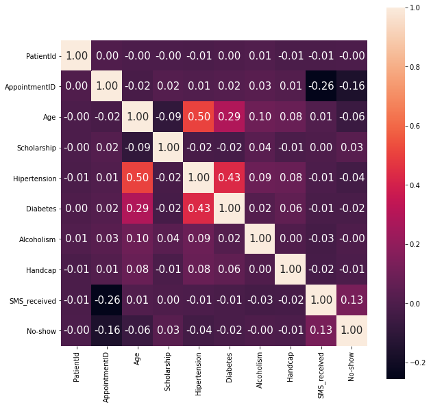

```python
 #Let's check out the correlations between the features of the each colunms in our data using heatmap to used in our analysis
correlation = app_df.corr()
fig, axes = plt.subplots(figsize=(10,10))
sns.heatmap(correlation, vmax=1, cbar=True, annot=True, square=True, fmt='.2f', annot_kws={'size': 15});
```

The heatmap show three correlation:

1. Hipertension and Diabetes
2. Diabetes and Age
3. Hipertension and Age

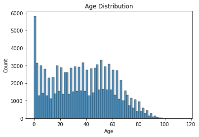

```python
col=app_df.columns
def plothistogram(col):
    sns.histplot(data=app_df, x=col)
    plt.title('Age Distribution')
plothistogram('Age')
```

The chart gives the age distribution to count. And it happens that the ages around 0 to 1 yrear has the highest count. So exculding this, it gives a uniform distribution untilaround age 65years when it start to decline.

## Q1 What percentage of patient show up and didn't?

```python
# The Age of the patient with the No show
app_df['Age'].nunique()
```

```
103
```

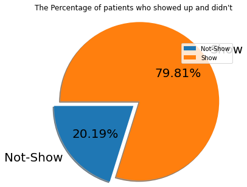

```python
label_Names = ["Not-Show", "Show"]
Age_data = [app_df.loc[(app_df['No-show'] == 1)].count()[0], app_df.loc[(app_df['No-show'] == 0)].count()[0]]
explode = (0, 0.15)
plt.axis('equal');
plt.pie(Age_data,radius=1.5,shadow=True ,labels = label_Names,explode=explode, startangle=180,autopct='%0.2f%%',textprops = {"fontsize":20})
plt.title("The Percentage of patients who showed up and didn't",y=1.2)
plt.legend(loc='best');
```

The pie shows distribution of the percentage of patient that show and those that did not. it gives a 20.19% of patient that did not show to 79.81% (approx 80%) that showed. this is four times that of the patient that the not shoed.

```
   No-show    Age
0        0  88207
1        1  22319
```

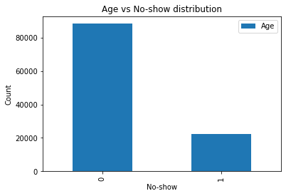

```python
#Checking the number of No-show to Age column
age_df= app_df.groupby('No-show', as_index=False)["Age"].count()
print(age_df)

app_df.groupby(['No-show'])['Age'].count().plot(kind = 'bar', title='Age vs No-show distribution').set_ylabel('Count')
plt.legend()
```

#### From the histogram plot, we can see that between ages 0 to 65yrs, it is almost uniform but from 65yrs and above there seems to be a decline.

this acan be atrributed to the type of treatment and diseases the hospital specilized in. secondly, most of the hospital patient are between the ages of 0-65yrs and are not majorly associated with the kinds of disesases listed out .

## Q2. Which of the gender misses their appointment the most?

```python
#Which of the gender misses their appointment the most

app_df['Gender'].nunique()
```

```
2
```

```python
df_f= app_df[app_df['Gender']== 'F']
df_m= app_df[app_df['Gender'] =='M']
```

```
No-show
0    57245
1    14594
Name: Gender, dtype: int64
```

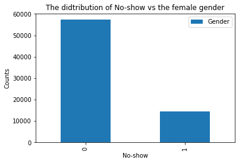

```python
counts = df_f.groupby(['No-show'])['Gender'].count()
print(counts)
df_f.groupby(['No-show'])['Gender'].count().plot(kind = 'bar', title='The didtribution of No-show vs the female gender',).set_ylabel('Counts')
plt.legend()
```

```python
# this gives the percentage of female gender that show and did not show with respect to their gender type only
per = counts/71839
per
```

```
No-show
0    0.796851
1    0.203149
Name: Gender, dtype: float64
```

```python
#the amount of male patient in the data set with respect to the No-show column.
counts_m= df_m.groupby(['No-show'])['Gender'].count()
counts_m
```

```
No-show
0    30962
1     7725
Name: Gender, dtype: int64
```

```python
# percentage of the male gender. this shows also that 80% of them did not show up. This is with respect to the mle gender only
per_m= counts_m/38687
per_m
```

```
No-show
0    0.800321
1    0.199679
Name: Gender, dtype: float64
```

```python
app_df
```

|  | PatientId | AppointmentID | Gender | ScheduledDay | AppointmentDay | Age | Neighbourhood | Scholarship | Hipertension | Diabetes | Alcoholism | Handcap | SMS_received | No-show |
| --- | --- | --- | --- | --- | --- | --- | --- | --- | --- | --- | --- | --- | --- | --- |
| 0 | 2.987250e+13 | 5642903 | F | 2016-04-29 18:38:08+00:00 | 2016-04-29 00:00:00+00:00 | 62 | JARDIM DA PENHA | 0 | 1 | 0 | 0 | 0 | 0 | 0 |
| 1 | 5.589978e+14 | 5642503 | M | 2016-04-29 16:08:27+00:00 | 2016-04-29 00:00:00+00:00 | 56 | JARDIM DA PENHA | 0 | 0 | 0 | 0 | 0 | 0 | 0 |
| 2 | 4.262962e+12 | 5642549 | F | 2016-04-29 16:19:04+00:00 | 2016-04-29 00:00:00+00:00 | 62 | MATA DA PRAIA | 0 | 0 | 0 | 0 | 0 | 0 | 0 |
| 3 | 8.679512e+11 | 5642828 | F | 2016-04-29 17:29:31+00:00 | 2016-04-29 00:00:00+00:00 | 8 | PONTAL DE CAMBURI | 0 | 0 | 0 | 0 | 0 | 0 | 0 |
| 4 | 8.841186e+12 | 5642494 | F | 2016-04-29 16:07:23+00:00 | 2016-04-29 00:00:00+00:00 | 56 | JARDIM DA PENHA | 0 | 1 | 1 | 0 | 0 | 0 | 0 |
| ... | ... | ... | ... | ... | ... | ... | ... | ... | ... | ... | ... | ... | ... | ... |
| 110522 | 2.572134e+12 | 5651768 | F | 2016-05-03 09:15:35+00:00 | 2016-06-07 00:00:00+00:00 | 56 | MARIA ORTIZ | 0 | 0 | 0 | 0 | 0 | 1 | 0 |
| 110523 | 3.596266e+12 | 5650093 | F | 2016-05-03 07:27:33+00:00 | 2016-06-07 00:00:00+00:00 | 51 | MARIA ORTIZ | 0 | 0 | 0 | 0 | 0 | 1 | 0 |
| 110524 | 1.557663e+13 | 5630692 | F | 2016-04-27 16:03:52+00:00 | 2016-06-07 00:00:00+00:00 | 21 | MARIA ORTIZ | 0 | 0 | 0 | 0 | 0 | 1 | 0 |
| 110525 | 9.213493e+13 | 5630323 | F | 2016-04-27 15:09:23+00:00 | 2016-06-07 00:00:00+00:00 | 38 | MARIA ORTIZ | 0 | 0 | 0 | 0 | 0 | 1 | 0 |
| 110526 | 3.775115e+14 | 5629448 | F | 2016-04-27 13:30:56+00:00 | 2016-06-07 00:00:00+00:00 | 54 | MARIA ORTIZ | 0 | 0 | 0 | 0 | 0 | 1 | 0 |

110526 rows × 14 columns

```python
# Total number of patient that missied appointment (including both gender)
t_no= app_df[app_df['No-show'] == 0].count()
g_no= t_no['Gender']
```

```python
#percentage of female gender that missed their appointment
per_f=(57245/g_no)
per_f
```

```
0.6489847744510073
```

```python
#percentage of male gender that missed their appointment
1-per_f
```

```
0.35101522554899267
```

```python
app_df.columns
```

```
Index(['PatientId', 'AppointmentID', 'Gender', 'ScheduledDay',
       'AppointmentDay', 'Age', 'Neighbourhood', 'Scholarship', 'Hipertension',
       'Diabetes', 'Alcoholism', 'Handcap', 'SMS_received', 'No-show'],
      dtype='object')
```

## Q3. How many of the patient took the scholarship and show up, and What percentage of patient who took the scholarship and did not?

```python
app_df['Scholarship'].nunique()
```

```
2
```

```python
app_df["Scholarship"].value_counts()
```

```
0    99665
1    10861
Name: Scholarship, dtype: int64
```

```python
df_0= app_df.query('Scholarship == 0')
df_1= app_df.query('Scholarship == 1')
```

```python
df_1.groupby(['No-show'])['Scholarship'].count()
```

```
No-show
0    8283
1    2578
Name: Scholarship, dtype: int64
```

```
Scholarship
0    0.901734
1    0.098266
Name: PatientId, dtype: float64
```

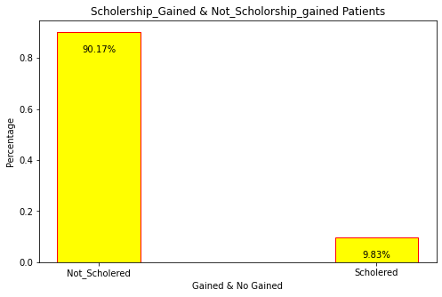

```python
# Plot percentage of patient who take scholarship and those who don't take:
scholarship= app_df.groupby('Scholarship').count()['PatientId']/app_df['PatientId'].count()
print(scholarship)

# Plotting Results:
x=[1,2]
y= scholarship.values
fig=plt.figure(figsize=(8,5))
plt.bar(x,y,width=0.3,edgecolor='red',facecolor='yellow')
plt.xticks(x,['Not_Scholered','Scholered']);
for xx,yy in zip(x,y):
    plt.text(xx,yy-0.08, str((yy*100).round(decimals=2)) + '%' , ha='center')

plt.xlabel('Gained & No Gained')
plt.ylabel('Percentage')
plt.title('Scholership_Gained & Not_Scholorship_gained Patients')
```

Also we can see from the plot that 90.17% did not take the scholarship, While 9.83% took the scholarship.

```python
app_df.groupby('Scholarship').mean()
```

| Scholarship | PatientId | AppointmentID | Age | Hipertension | Diabetes | Alcoholism | Handcap | SMS_received | No-show |
| --- | --- | --- | --- | --- | --- | --- | --- | --- | --- |
| 0 | 1.477366e+14 | 5.674772e+06 | 37.794612 | 0.199839 | 0.073988 | 0.028415 | 0.022706 | 0.320845 | 0.198074 |
| 1 | 1.452618e+14 | 5.680189e+06 | 30.616242 | 0.173465 | 0.052389 | 0.048614 | 0.018046 | 0.322714 | 0.237363 |

## Q5. How many patient received sms and showed up?

```python
app_df['SMS_received'].nunique()
```

```
2
```

```python
app_df['SMS_received'].value_counts()
```

```
0    75044
1    35482
Name: SMS_received, dtype: int64
```

```python
df_01= app_df.query('SMS_received == 0')
df_11= app_df.query('SMS_received == 1')
```

```
No-show
0    25698
1     9784
Name: SMS_received, dtype: int64
```

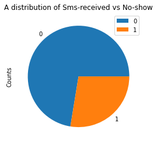

```python
print(df_11.groupby(['No-show'])['SMS_received'].count())
df_11.groupby(['No-show'])['SMS_received'].count().plot(kind = 'pie', title= 'A distribution of Sms-received vs No-show').set_ylabel('Counts')
plt.legend()
```

## Q5 Is SMS_received and gender affect the patient's show up?

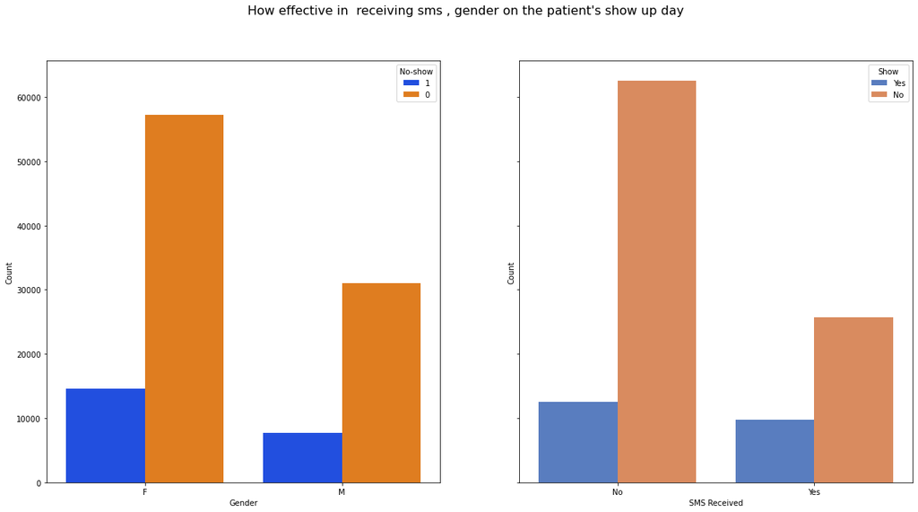

```python
fig, (ax1, ax2) = plt.subplots(ncols=2, sharey=True)
hue_order=[1,0]

sms_df=app_df['SMS_received'].map({1:'Yes',0: 'No'})

sns.countplot(x='Gender', data=app_df, hue='No-show', ax=ax1, palette='bright', hue_order=hue_order)
sns.countplot(x= sms_df, data=app_df, hue='No-show', ax=ax2, palette='muted', hue_order=hue_order)
fig.set_figwidth(20)
fig.set_figheight(10)
fig.suptitle("How effective in  receiving sms , gender on the patient's show up day", fontsize=16);
ax1.set(xlabel='Gender', ylabel='Count')
ax2.set(xlabel='SMS Received', ylabel='Count')
#place legend in upper left of plot
plt.legend(loc='upper right', title='Show',labels=['Yes', 'No']);
```

# Q6 Is any deseases (Hipertension , Diabetes ) affect the patient's show up?

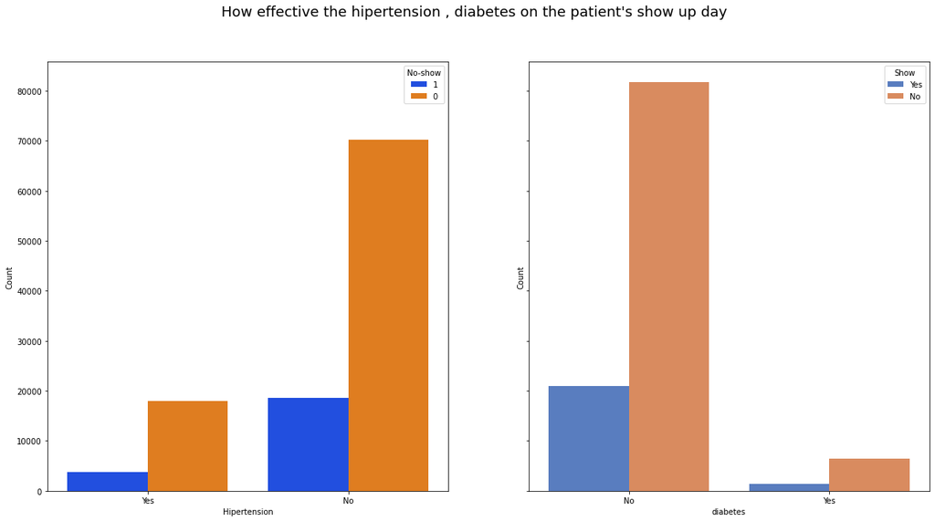

```python
fig, (ax1, ax2) = plt.subplots(ncols=2, sharey=True)
hue_order=[1,0]

hip_df=app_df['Hipertension'].map({1:'Yes',0: 'No'})
dia_df=app_df['Diabetes'].map({1:'Yes',0: 'No'})


sns.countplot(x=hip_df, data=app_df, hue= 'No-show', ax=ax1, palette='bright', hue_order=hue_order)
sns.countplot(x=dia_df, data=app_df, hue= 'No-show', ax=ax2, palette='muted', hue_order=hue_order)

fig.set_figwidth(20)
fig.set_figheight(10)
fig.suptitle("How effective the hipertension , diabetes on the patient's show up day", fontsize=18);

ax1.set(xlabel='Hipertension', ylabel='Count')
ax2.set(xlabel='diabetes', ylabel='Count')
#place legend in upper left of plot
plt.legend(loc='upper right', title='Show',labels=['Yes', 'No']);
```

# CONCLUSION

Percentage of patients who show up on their appointments represents 79.81%

Percentage of patients who Don't show up on their appointments represents 20.19%

There seems no strong correlation between any feature with show up as all correlation values are below 0.5.

SMS feature slightly has an effect on patient's show up.

Also would employ further investigation on; Using the appointmentday, scheduleday, Neighborhood, and No-show columns in looking out for patterns, relationships.

## Limitations and Missing Information

The data set only covers a range of a month and 10 days (2016-04-29 and 2016-06-08), which is very small sample with respect to long duration of time (6 months and above).

If more information can be provided on the average income of each pateint this would be useful.

if more details would be given on the specific kind of jobs, activities each persons engage in.